# R4Photobiology Start-up Guide

Maxime Durand

28/06/2022

# Foreword

This document is made with the objective of being a start-up point to delve into the possibilities offered by the R4Photobiology package suite. Only a brief overview of the main aspect will be descibed here. For more information and more specific help regarding each of the package, please consult the [webpage.](https://www.r4photobiology.info/package-status/) For more a better theoretical understanding of the concepts discussed below, please have a look at ***Beyond the visible: a handbook of best practice in plant UV photobiology** available [here.](https://helda.helsinki.fi/handle/10138/37558)

# Installation

- To process raw spectrometer data, we first need to install the packages **ooacquire** and **rOmnidriver**. These packages require that some dependencies be installed first:
  - Rtools42 (for R version 4.2.X)
  - Java (32 & 64 bits)
  - Cran packages (rJava & devtools)

**1. Rtools42**

Rtools42 can be accessed through [this page.](https://cran.r-project.org/bin/windows/Rtools/rtools42/rtools.html) Older versions of Rtools for older version or R are available [here.](https://cran.r-project.org/bin/windows/Rtools/) The default installation location will be *C:/Rtools42/*

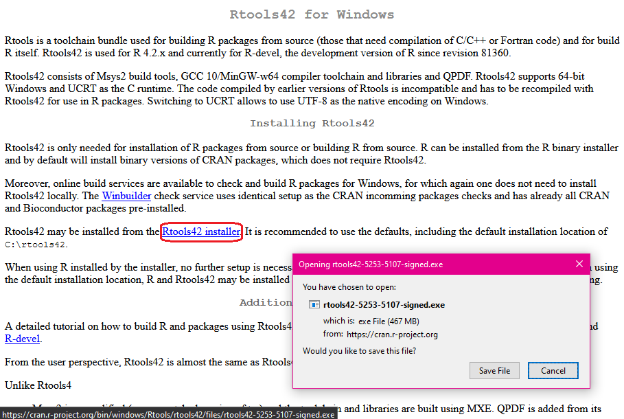

**2. Java**

On most computers, **both 32 bits and 64 bits Java** need to be installed and up to date. Download links for Java can be found [here.](https://www.java.com/en/download/manual.jsp)

[figure not shown]

You will also need the Java Development Kit, available [here.](https://www.oracle.com/java/technologies/downloads/#jdk18-windows)

[figure not shown]

**3. CRAN packages**

**rJava** provide the interface for R to use Java, and **devtools** will let us install packages directly from *GitHub*.

```r
# Install packages from CRAN
install.packages("photobiology")
install.packages("photobiologyWavebands")
install.packages("photobiologyPlants")
install.packages("photobiologyFilters")
install.packages("photobiologyLamps")
install.packages("photobiologyLEDs")

install.packages("ggspectra")
install.packages("tidyverse")
install.packages("rJava")
install.packages("devtools")
```

If asked, install from sources the packages that needs compilation.

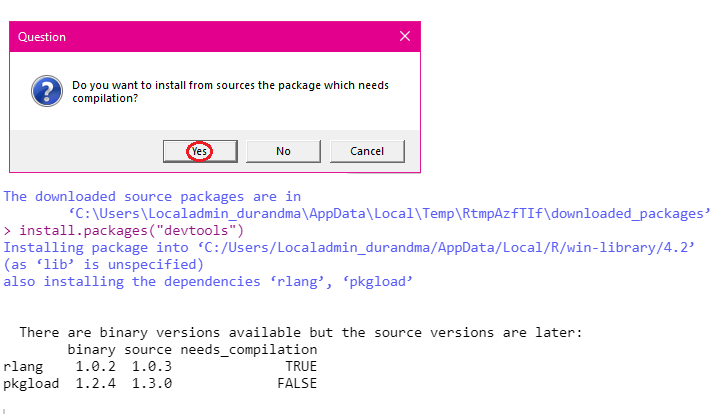

**Warning:** If source packages fail to be installed properly, you may not be able to go further. This could be due to a bad installation of *Rtools*. The best solution is to check the previous steps to make sure everything was installed properly, and is recognized by R. If all else fail, the following code forces the installation of binaries (usually an older version), however it does not guarantee that the next steps will work.

```r
install.packages("rlang", type = "binary")
install.packages("pkgdown", type = "binary")
```

**An example of a failed source installation:** *Here, R was looking for a version of Rtools called **rtools42_test** that did not exist on this computer.*

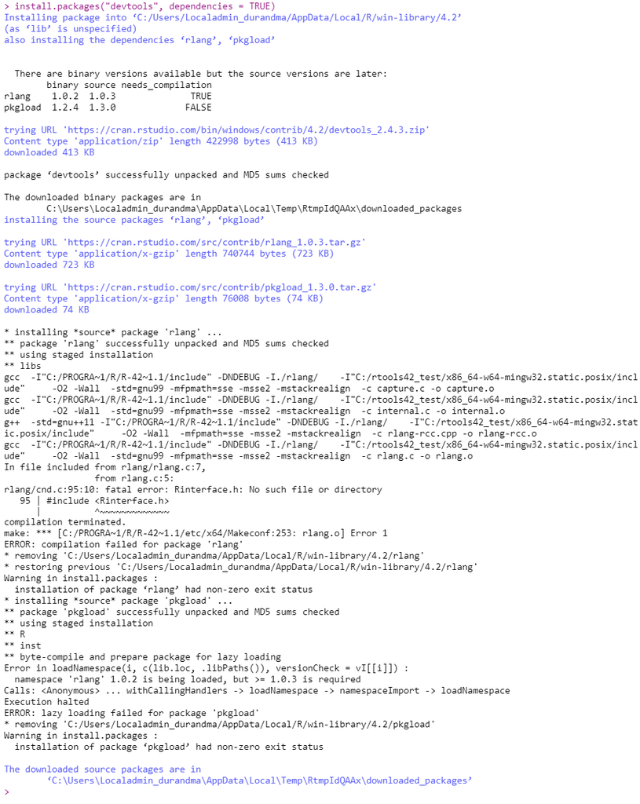

**4. rOmnidriver**

Now that all dependencies are installed, we can get the *rOmnidriver* package from GitHub. This is what the console should look like:

```r
devtools::install_github("aphalo/romnidriver")
```

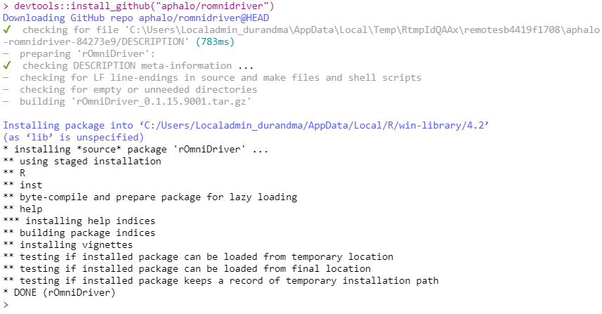

**5. ooacquire**

Finally, the *ooacquire* package can similarly be installed from GitHub. The console should look like this:

```r
devtools::install_github("aphalo/ooacquire")
```

Again, you may need to install from sources the packages that needs compilation.

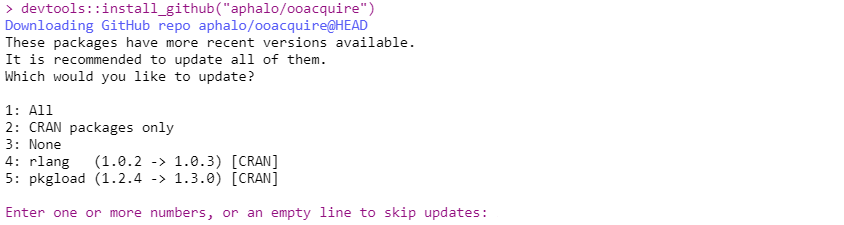

A proper installation of *ooacquire* should look like this:

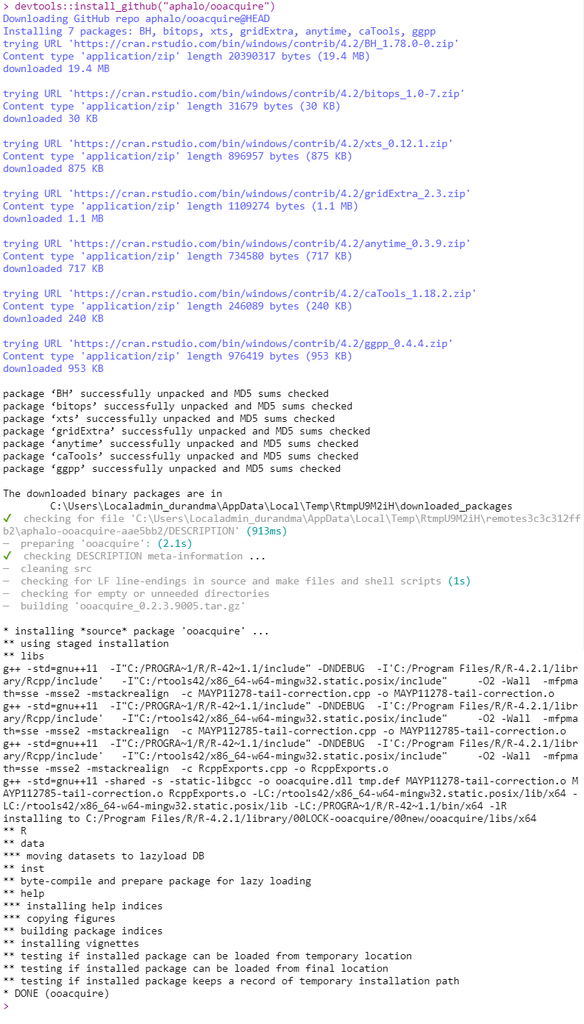

# Processing step-by-step

```r
# Load necessary packages
library(photobiology)
library(photobiologyWavebands)
library(photobiologyPlants)
library(ooacquire)
```

**1. Import spectrometer data as spectra in R**

- First, one has to import the wavelength and raw count data in R. Here, wavelength are in a vector called “**wvl**”, and three raw counts data are the objects **light**, **filter**, and **dark**. Data can also be imported as data.frame if one choses.

```r
# Imported data
head(wvl, 50)
```

```
##  [1] 187.82 188.30 188.78 189.26 189.73 190.21 190.69 191.17 191.64 192.12
## [11] 192.60 193.07 193.55 194.03 194.51 194.98 195.46 195.94 196.42 196.89
## [21] 197.37 197.85 198.32 198.80 199.28 199.76 200.23 200.71 201.19 201.66
## [31] 202.14 202.62 203.09 203.57 204.05 204.53 205.00 205.48 205.96 206.43
## [41] 206.91 207.39 207.86 208.34 208.82 209.29 209.77 210.25 210.72 211.20
```

```r
head(light, 50)
```

```
##  [1] 2243 2187 2147 2153 4826 5883 6826 6815 6931 6786 6681 6712 6789 6747 6898
## [16] 6771 6896 6791 6819 7163 6915 6790 6841 6867 6857 6979 6850 6859 6914 6955
## [31] 6923 6787 6873 6819 6962 6968 6818 6883 6945 6947 6968 7187 6945 6923 6923
## [46] 6970 6992 6859 6835 6873
```

```r
head(filter, 50)
```

```
##  [1] 2239 2185 2148 2151 4865 5820 6680 6814 6841 6710 6704 6633 6800 6761 6856
## [16] 6844 6862 6742 6776 7116 6801 6804 6788 6793 6916 6928 6920 6860 6958 6948
## [31] 6972 6800 6937 6810 6897 7023 6836 6919 7060 6862 6956 7119 6919 6924 6917
## [46] 6988 6980 6924 6890 6967
```

```r
head(dark, 50)
```

```
##  [1] 2240 2184 2148 2149 4812 5764 6648 6724 6711 6694 6700 6578 6724 6656 6733
## [16] 6665 6801 6764 6760 6976 6662 6792 6805 6716 6775 6811 6843 6742 6921 6841
## [31] 6912 6635 6845 6742 6876 6879 6833 6794 6959 6915 6878 7028 6846 6829 6847
## [46] 6941 6876 6788 6822 6804
```

- Then, each scan is built by associating the raw counts and the wavelength in one “**raw spectrum**” object.

```r
# Building each spectra
light.spct <- raw_spct(w.length = wvl, counts = light)
filter.spct <- raw_spct(w.length = wvl, counts = filter)
dark.spct <- raw_spct(w.length = wvl, counts = dark)
```

```r
light.spct
```

```
## Object: raw_spct [2,068 x 2]
## Wavelength range 187.82-1117.14 nm, step 0.41-0.48 nm
##
## # A tibble: 2,068 × 2
##    w.length counts
##       <dbl>  <dbl>
##  1     188.   2243
##  2     188.   2187
##  3     189.   2147
##  4     189.   2153
##  5     190.   4826
##  6     190.   5883
##  7     191.   6826
##  8     191.   6815
##  9     192.   6931
## 10     192.   6786
## # … with 2,058 more rows
```

```r
filter.spct
```

```
## Object: raw_spct [2,068 x 2]
## Wavelength range 187.82-1117.14 nm, step 0.41-0.48 nm
##
## # A tibble: 2,068 × 2
##    w.length counts
##       <dbl>  <dbl>
##  1     188.   2239
##  2     188.   2185
##  3     189.   2148
##  4     189.   2151
##  5     190.   4865
##  6     190.   5820
##  7     191.   6680
##  8     191.   6814
##  9     192.   6841
## 10     192.   6710
## # … with 2,058 more rows
```

```r
dark.spct
```

```
## Object: raw_spct [2,068 x 2]
## Wavelength range 187.82-1117.14 nm, step 0.41-0.48 nm
##
## # A tibble: 2,068 × 2
##    w.length counts
##       <dbl>  <dbl>
##  1     188.   2240
##  2     188.   2184
##  3     189.   2148
##  4     189.   2149
##  5     190.   4812
##  6     190.   5764
##  7     191.   6648
##  8     191.   6724
##  9     192.   6711
## 10     192.   6694
## # … with 2,058 more rows
```

- All three scans can also be merge into one “**raw multi-spectra**” object.

```r
# Merging into a multi-spectra object
raw.mspct <- as.raw_mspct(list("light" = light.spct, "filter" = filter.spct, "dark" = dark.spct))
raw.mspct
```

```
## Object: raw_mspct [3 x 1]
## --- Member: light ---
## Object: raw_spct [2,068 x 2]
## Wavelength range 187.82-1117.14 nm, step 0.41-0.48 nm
##
## # A tibble: 2,068 × 2
##    w.length counts
##       <dbl>  <dbl>
##  1     188.   2243
##  2     188.   2187
##  3     189.   2147
##  4     189.   2153
##  5     190.   4826
##  6     190.   5883
##  7     191.   6826
##  8     191.   6815
##  9     192.   6931
## 10     192.   6786
## # … with 2,058 more rows
## --- Member: filter ---
## Object: raw_spct [2,068 x 2]
## Wavelength range 187.82-1117.14 nm, step 0.41-0.48 nm
##
## # A tibble: 2,068 × 2
##    w.length counts
##       <dbl>  <dbl>
##  1     188.   2239
##  2     188.   2185
##  3     189.   2148
##  4     189.   2151
##  5     190.   4865
##  6     190.   5820
##  7     191.   6680
##  8     191.   6814
##  9     192.   6841
## 10     192.   6710
## # … with 2,058 more rows
## --- Member: dark ---
## Object: raw_spct [2,068 x 2]
## Wavelength range 187.82-1117.14 nm, step 0.41-0.48 nm
##
## # A tibble: 2,068 × 2
##    w.length counts
##       <dbl>  <dbl>
##  1     188.   2240
##  2     188.   2184
##  3     189.   2148
##  4     189.   2149
##  5     190.   4812
##  6     190.   5764
##  7     191.   6648
##  8     191.   6724
##  9     192.   6711
## 10     192.   6694
## # … with 2,058 more rows
##
## --- END ---
```

- Each scan can be shown with the following line:

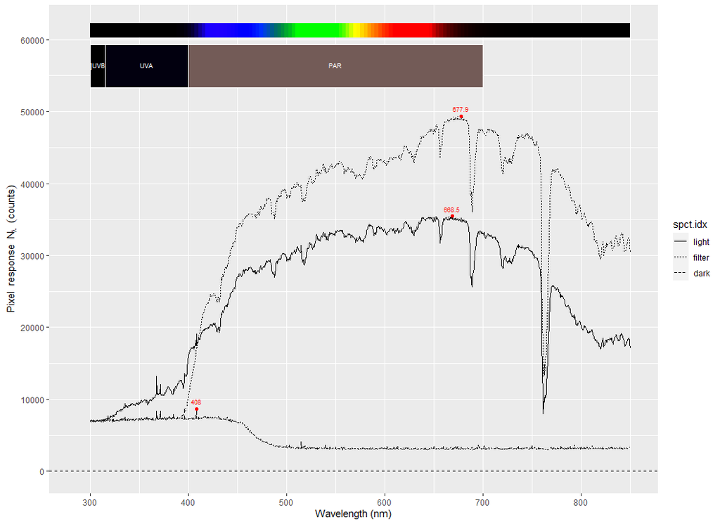

```r
autoplot(raw.mspct, range = c(300, 850))
```

**2. Conversion to counts per seconds**

- Now, the processing of each spectrum can begin. First, one has to consider counts outside the range of the spectrometer as missing data. Typically, those values are recorded as the maximum count possible by the spectrometer (*e.g.* 60 000 counts) and must be changed to *NA*.

```r
max.counts = 60000

temp.light.spct <- trim_counts(light.spct, range = c(NA, max.counts-1))
temp.filter.spct <- trim_counts(filter.spct, range = c(NA, max.counts-1))
temp.dark.spct <- trim_counts(dark.spct, range = c(NA, max.counts-1))
```

- By a phenomenon similar to “blooming” in camera sensors, wells adjacents to saturated ones may give inflated values. This removes data from these wells. This is because when a sensor well gets saturated some of the charge migrates to adjacent wells in the detector increasing their readings.

```r
temp.light.spct <- bleed_nas(temp.light.spct)
temp.filter.spct <- bleed_nas(temp.filter.spct)
temp.dark.spct <- bleed_nas(temp.dark.spct)
```

- Some known bad pixels, where the spectrometer gives consistently bad values, may need to be removed. This is done by replacing the values of the bad pixels by the average of the neighboring pixels.

```r
skip_bad_pixs <- function(x, bad.pixs = NULL)
{
  if(is.null(bad.pixs)){return(x)}

  counts.cols <- grep("^counts", names(x), value = TRUE)
  for (col in counts.cols) {
    x[bad.pixs, col] <-
      (x[bad.pixs - 1, col] + x[bad.pixs + 1, col]) / 2
  }
  return(x)
}

bad_pixs <- c(123, 380, 388, 467, 697, 1829, 1994)
tmp.light.spct <- skip_bad_pixs(temp.light.spct, bad.pixs = bad_pixs)
tmp.filter.spct <- skip_bad_pixs(temp.filter.spct, bad.pixs = bad_pixs)
tmp.dark.spct <- skip_bad_pixs(temp.dark.spct, bad.pixs = bad_pixs)
```

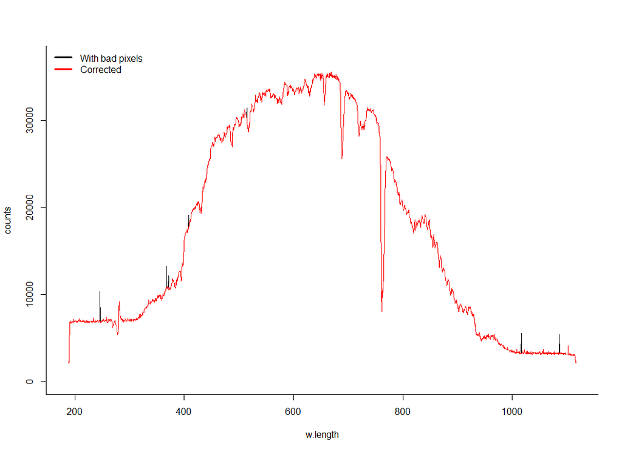

- With some instruments, a linearization correction to raw counts data is necessary. This is either retrieved from the instrument’s firmware, or possibly a replacement set by the user.

**An example of a linearization function from our spectrometer**

[figure not shown]

```r
linearizeCounts <- function(x, coef)
{
  y <- x * coef
  return(y)
}

slope = 1.03403933042735

temp.light.spct$counts <- linearizeCounts(tmp.light.spct$counts, coef = slope)
temp.filter.spct$counts <- linearizeCounts(tmp.filter.spct$counts, coef = slope)
temp.dark.spct$counts <- linearizeCounts(tmp.dark.spct$counts, coef = slope)
```

**Effect on our example light spectrum:**

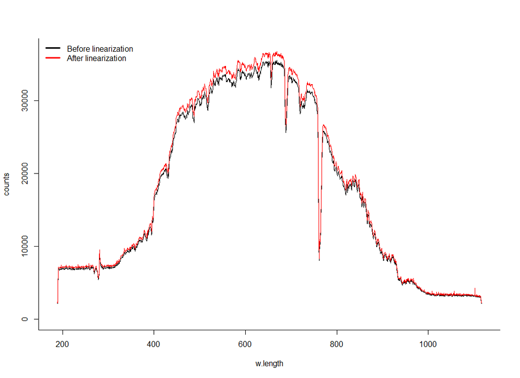

- To remove counts due to electrical noise, a set of known *dark* pixels (*e.g.* manually taped to prevent any photon to be collected) is averaged, and removed from the rest of the data. Here the dak pixels are the first four:

```r
inst.dark.pixs = 1:4
inst.dark.wl <- range(temp.light.spct[["w.length"]][inst.dark.pixs])

tmp.light.spct <- fshift(temp.light.spct, range = inst.dark.wl)
tmp.filter.spct <- fshift(temp.filter.spct, range = inst.dark.wl)
tmp.dark.spct <- fshift(temp.dark.spct, range = inst.dark.wl)
```

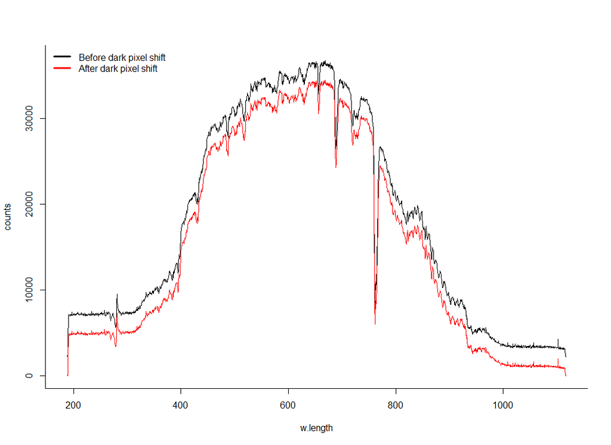

- Finally, raw counts can be **converted in counts per seconds** (or CPS), using the integration time.

```r
counts_to_cps <- function(x, integ.time.ms)
{
  y <- cps_spct(w.length = x$w.length, cps = x$counts / integ.time.ms * 1e3)
  return(y)
}

integ <- 3500

cps.light.spct <- counts_to_cps(tmp.light.spct, integ.time.ms = integ)
cps.filter.spct <- counts_to_cps(tmp.filter.spct, integ.time.ms = integ)
cps.dark.spct <- counts_to_cps(tmp.dark.spct, integ.time.ms = integ)

# Merging into a multi-spectra object
cps.mspct <- as.cps_mspct(list("light" = cps.light.spct, "filter" = cps.filter.spct, "dark" = cps.dark.spct))
cps.mspct
```

```
## Object: cps_mspct [3 x 1]
## --- Member: light ---
## Object: cps_spct [2,068 x 2]
## Wavelength range 187.82-1117.14 nm, step 0.41-0.48 nm
##
## # A tibble: 2,068 × 2
##    w.length     cps
##       <dbl>   <dbl>
##  1     188.   19.4
##  2     188.    2.86
##  3     189.   -8.96
##  4     189.   -7.19
##  5     190.  783.
##  6     190. 1095.
##  7     191. 1373.
##  8     191. 1370.
##  9     192. 1404.
## 10     192. 1362.
## # … with 2,058 more rows
## --- Member: filter ---
## Object: cps_spct [2,068 x 2]
## Wavelength range 187.82-1117.14 nm, step 0.41-0.48 nm
##
## # A tibble: 2,068 × 2
##    w.length     cps
##       <dbl>   <dbl>
##  1     188.   18.6
##  2     188.    2.66
##  3     189.   -8.27
##  4     189.   -7.39
##  5     190.  794.
##  6     190. 1077.
##  7     191. 1331.
##  8     191. 1370.
##  9     192. 1378.
## 10     192. 1340.
## # … with 2,058 more rows
## --- Member: dark ---
## Object: cps_spct [2,068 x 2]
## Wavelength range 187.82-1117.14 nm, step 0.41-0.48 nm
##
## # A tibble: 2,068 × 2
##    w.length     cps
##       <dbl>   <dbl>
##  1     188.   19.1
##  2     188.    2.51
##  3     189.   -8.12
##  4     189.   -7.83
##  5     190.  779.
##  6     190. 1060.
##  7     191. 1321.
##  8     191. 1344.
##  9     192. 1340.
## 10     192. 1335.
## # … with 2,058 more rows
##
## --- END ---
```

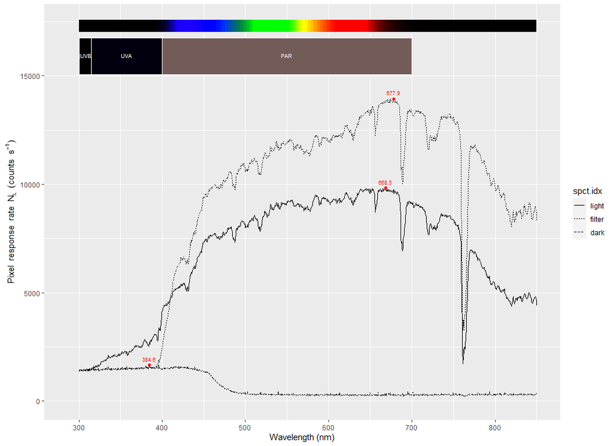

```r
autoplot(cps.mspct, range = c(300, 850))
```

**3. Dark correction**

A spectrometer measurement in the dark provides additional correction of the instrumental noise during data collection (*e.g.* due to temperature). The dark spectrum can be subtracted to both the data. The dark spectrum is deleted after that, as it has no other uses.

```r
dark_correction <- function(x, dark)
{
  z <- cps_mspct()

  drk <- x[[dark]]
  scans <- names(x)[-which(names(x) == dark)]

  for (i in scans)
  {
    z[[i]] <- x[[i]]
    z[[i]]$cps <- x[[i]]$cps - drk$cps
  }
  return(z)
}

ref.cps.mspct <- dark_correction(x = cps.mspct, dark = "dark")
```

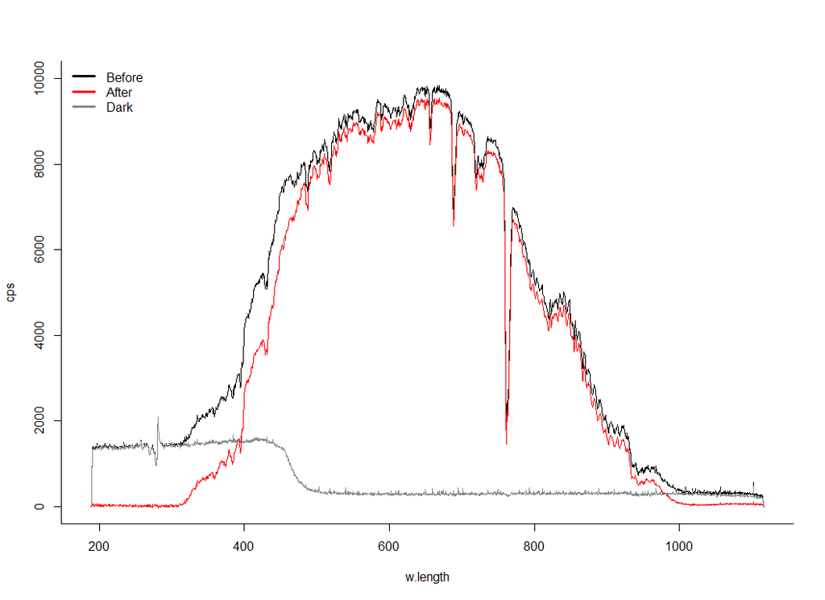

**4. Stray-light correction**

The monochromator inside the spectrometer does not perfectly transfer each radiation to the specific wavelength. This is **especially important for UVs where small differences can have a large impact.** To mitiguate this, two corrections are applied.

- The slit-tail correction

The figure below show the spectrum measured under a helium–neon laser which emits at a very narrow wavelength of 632.8 nm. An exponential fit in applied to the measured response. This fit is subtracted to the data, resulting in a limited residual slit tail.

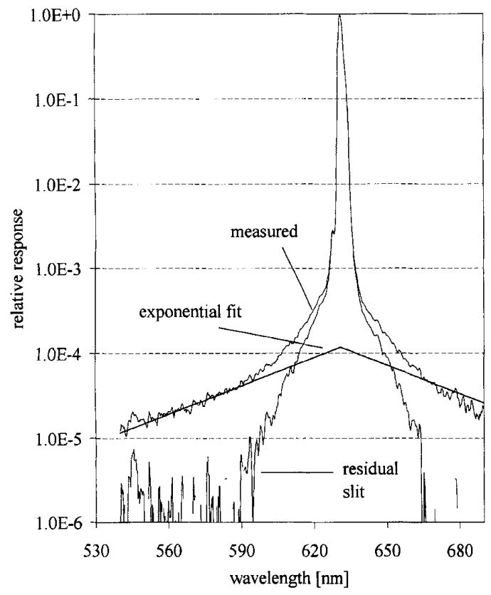

- The stray light correction (filter)

It is also recommended to take a recording of the light using a UV filter (*e.g.* polycarbonate filter).

The function then compute a ratio of *light/filter* in the waveband [193-209.5nm] (by default) that is supposed to be free of radiation (and thus give the same reading). In the example below, the ratio is **0.9799**.

$ratio_{dark} = \frac{light_{193-209.5nm}}{filter_{193-209.5nm}}$

Then, the function applies two different corrections based on wavelength:

- **For UV waveband [228.5-379nm]**, the recorded irradiance in the filter is divided by the ratio, and subtracted to the light scan:

$light_{corrected} = light_{228.5-379nm} - \frac{filter_{228.5-379nm}}{ratio_{dark}}$

- **For every wavelength > 379nm**, the recorded irradiance in the filter *in the waveband [360-379nm]* is divided by the ratio, and subtracted to the light scan:

$light_{corrected} = light_{> 379nm} - \frac{filter_{360-379nm}}{ratio_{dark}}$

```r
cor.cps.mspct <- filter_correction(x = ref.cps.mspct[["light"]], flt = ref.cps.mspct[["filter"]],
                                   stray.light.method = "sun",
                                   stray.light.wl = c(218.5, 228.5),
                                   flt.dark.wl = c(193, 209.5),
                                   flt.ref.wl = c(360, 379.5),
                                   verbose = TRUE)
```

```
## mean_flt_ratio_short is 0.9799
```

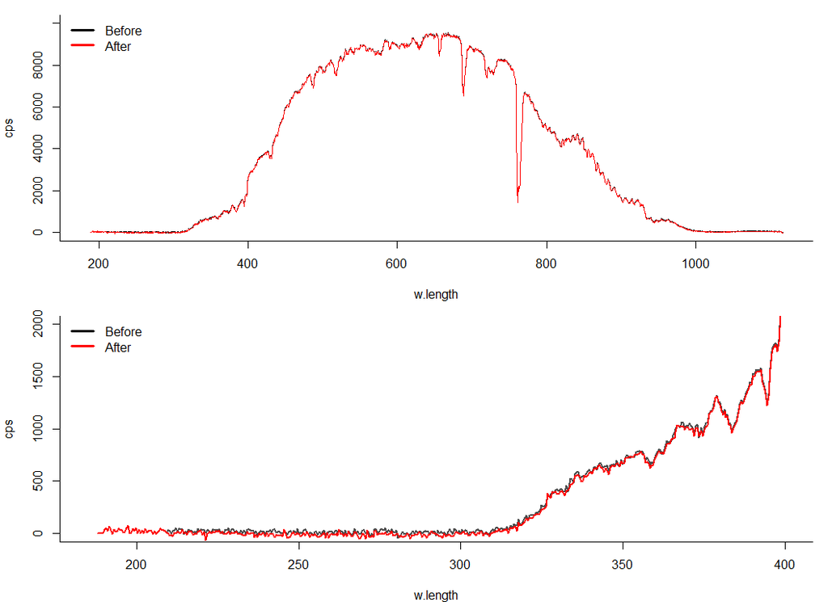

**In the case where no filter recording was taken**, a simpler correction of stray light can be applied. If the number of CPS in the waveband [218-228nm] (where there can be stray light) is higher than the CPS in the waveband [193-209nm] (where it is completely dark), then the average of the CPS in the waveband [218-228nm] is subtracted to the light scan:

$if$ $light_{218-228nm} > light_{193-209nm}:$

$light_{corrected} = light - light_{218-228nm}$

```r
cor2.cps.mspct <- no_filter_correction(x = ref.cps.mspct[["light"]],
                                       stray.light.wl = c(218.5, 228.5),
                                       flt.dark.wl = c(193, 209.5),
                                       verbose = TRUE)
```

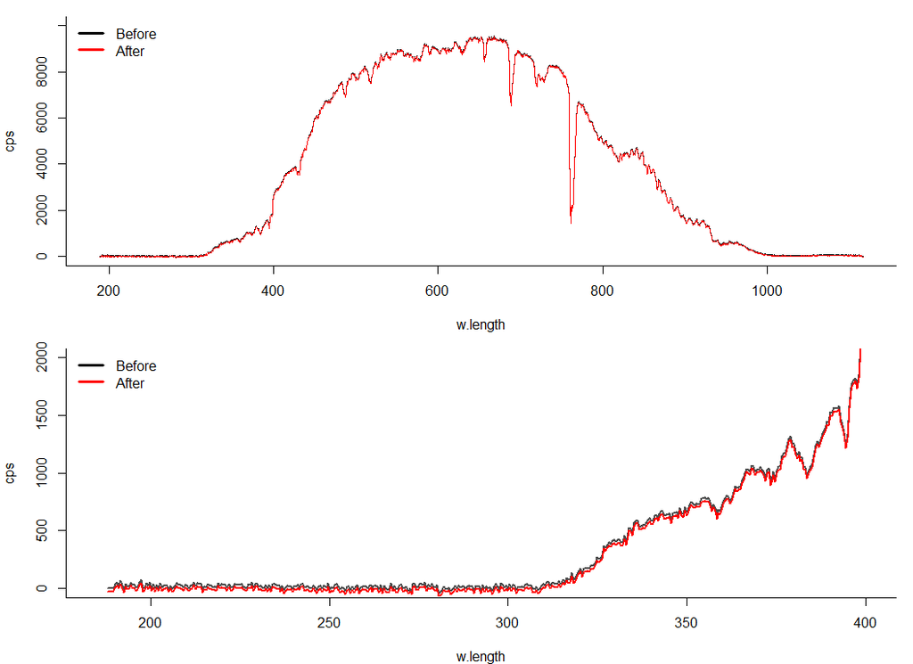

**5. Conversion from CPS to irradiance**

- **After all corrections are done, the final conversion from CPS to irradiance values is performed.** The conversion is based on a wavelength-dependent conversion factor, that is either provided by the manufacturer of the spectrometer, or calibrated with a lamp of a known output.

```r
cps_to_irrad <- function(x, conv_func, clip)
{
  y <- source_spct("w.length" = x$w.length, s.e.irrad = x$cps * conv_func)
  y <- clip_wl(y, c(251, 899))
  return(y)
}

conversion_factors <- which_descriptor("2017-10-06")[["inst.calib"]][["irrad.mult"]]
e.final.spct <- cps_to_irrad(x = cor.cps.mspct, conv_func = conversion_factors, clip = c(c(251, 899)))
```

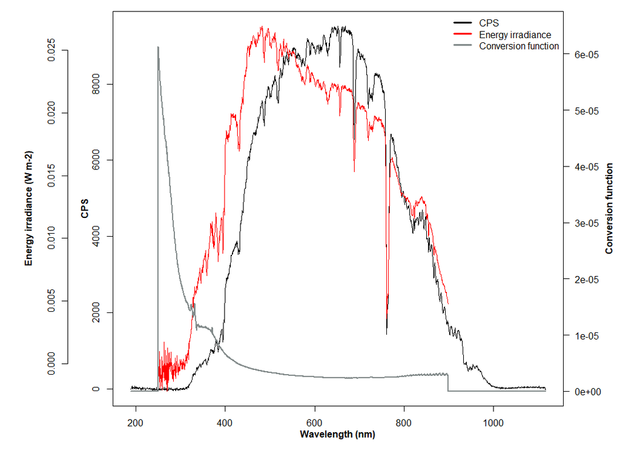

**We can now easily convert to photon irradiance.** Units are by default mol m-2 s-1

```r
q <- as_quantum_mol(w.length = e.final.spct$w.length, s.e.irrad = e.final.spct$s.e.irrad) * 1e6
q.final.spct <- source_spct(w.length = e.final.spct$w.length, s.q.irrad = q)

# The reverse can be done with the function as_energy()
```

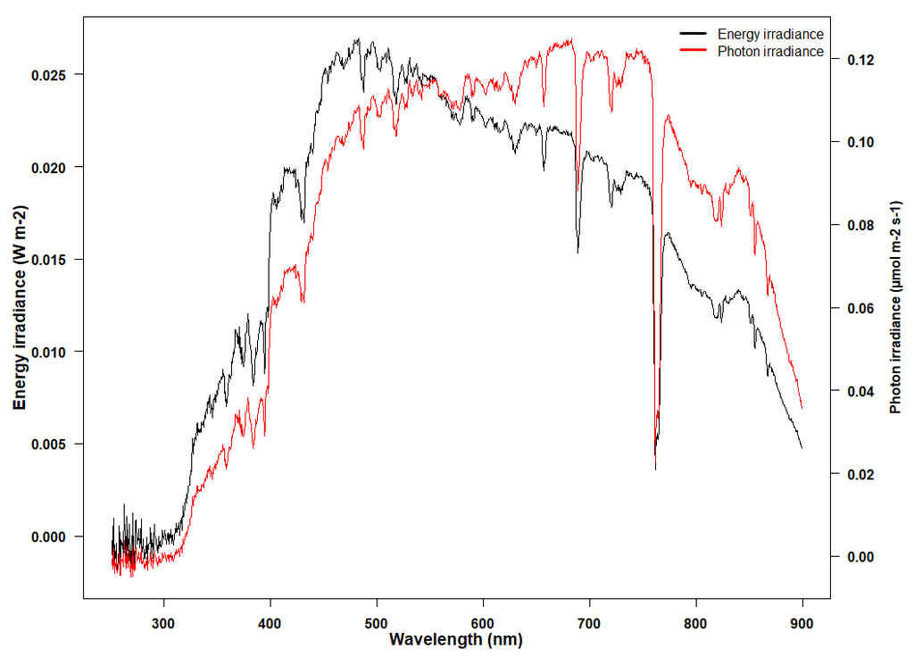

# Bracketing for precise UV measurements

When recording the whole spectrum, **UVs are often measured at less-than-optimal resolution**, since they represent a smaller portion of the total spectrum. Bracketing merges scans taken at different integration times to allows for the **recording of the whole spectrum at high resolution**.

Here we have two scans, one measured at low integration time (*short scan*), where all of the wavelengths are recorded, and one at high integration time (*long scan*), where only the UVs are recorded:

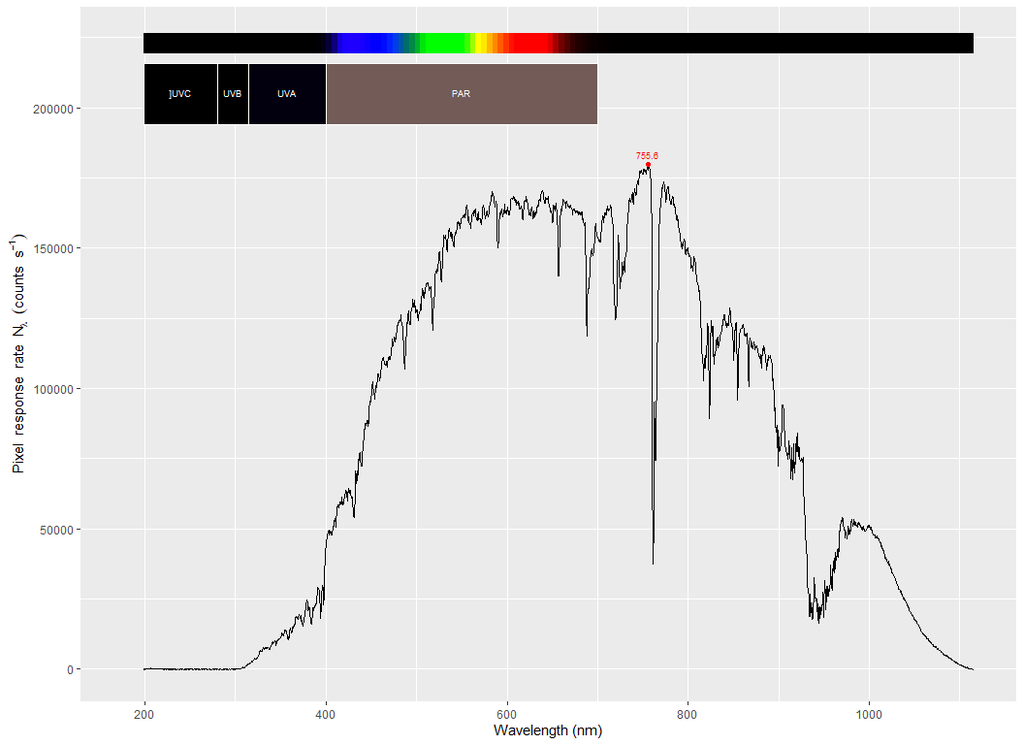

```r
short.names <- list(light = "MP1sun.txt", filter = "MP1sunPC.txt", dark = "MP1sundark.txt")
short <- s_irrad_corrected(x = short.names, descriptor =  which_descriptor("2020-06-10", ooacquire::MAYP112785_descriptors), correction.method = MAYP112785_sun.mthd, return.cps = TRUE)

long.names <- list(light = "MP1sunlong.txt", filter = "MP1sunlongPC.txt", dark = "MP1sunlongdark.txt")
long <- s_irrad_corrected(x = long.names, descriptor =  which_descriptor("2020-06-10", ooacquire::MAYP112785_descriptors), correction.method = MAYP112785_sun.mthd, return.cps = TRUE)

autoplot(short)
```

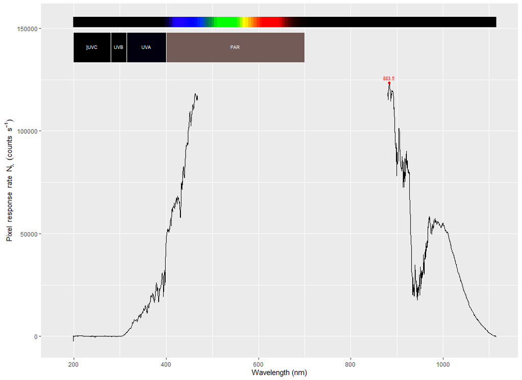

```r
autoplot(long)
```

In some conditions, **even if the two scans are taken right after the other, significant change in the light can occur**. Thus, one scan has to be scaled to the other to ensure proper merging. Here we scale the two scans based on the [250-380nm] waveband, using a polynomial equation of order 2:

```r
# Select CPS from 250nm to last recorded wavelength in long scan to apply correction on
short_wb <- short[short$w.length > 250 & short$w.length < 380, "cps"]
long_wb <- long[long$w.length > 250 & long$w.length < 380, "cps"]

# Fit a second order polynomial equation (because difference between long and short is not linear for smaller wavelengths)
library(minpack.lm)

f <- nlsLM(short_wb ~ a*long_wb^2 + b*long_wb + c, start = list(a = 1, b = 1, c = 1))
a = coef(f)[1]
b = coef(f)[2]
c = coef(f)[3]
```

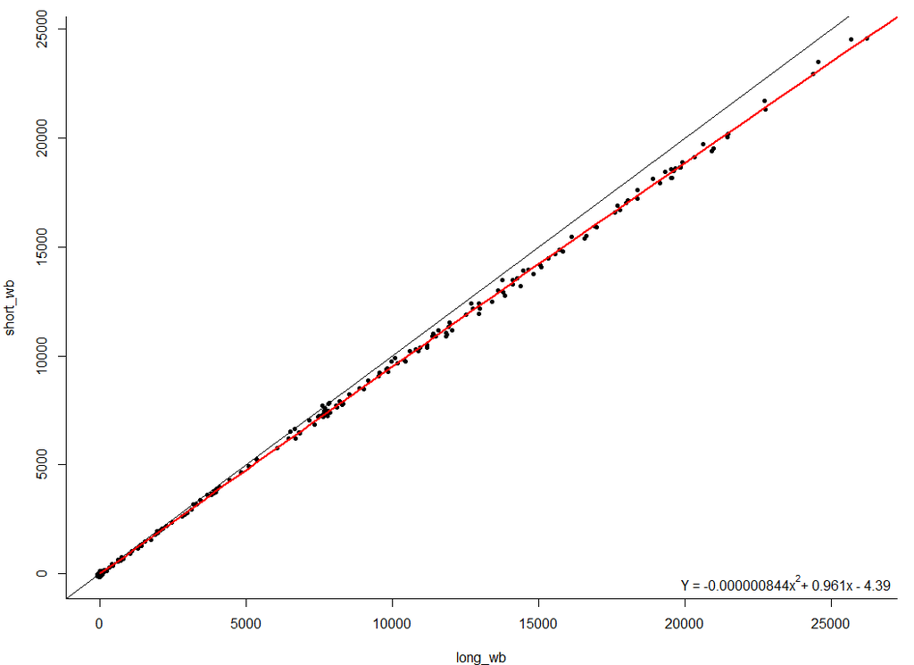

We can now apply the scaling:

```r
long_corrected <- long
long_corrected$cps <- a*long_corrected$cps^2 + b*long_corrected$cps + c
```

And finally, we bracket the scans, replacing the irradiance value in the short scans by the scaled long one for wavelengths < 380nm:

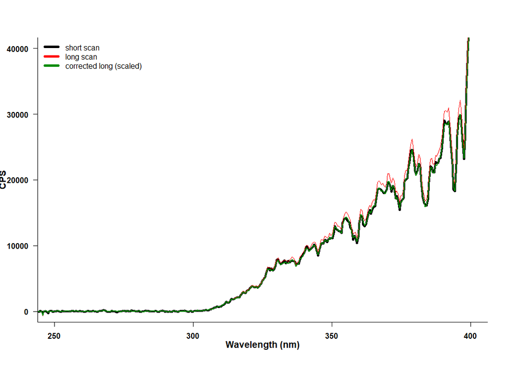

```r
short_bracketed <- short
short_bracketed[short_bracketed$w.length < 380,"cps"] <- long_corrected[long_corrected$w.length < 380,"cps"]
```

# Spectral ratios and waveband construction

Using the package **photobiologyWavebands**, we can construct a waveband object:

```r
PAR.wb <- waveband(c(400, 700), wb.name = "PAR")
UVA.wb <- waveband(c(315, 400), wb.name = "UVA")
UVB.wb <- waveband(c(280, 315), wb.name = "UVB")
UVC.wb <- waveband(c(100, 280), wb.name = "UVC")
UV.wb  <- waveband(c(100, 400), wb.name =  "UV")
```

A number of wavebands are already available in the package, with different definitions (see the help page of each for more details):

```r
PAR()
```

```
## PAR
## low (nm) 400
## high (nm) 700
## weighted none
```

```r
UVB("ISO")
```

```
## UVB.ISO
## low (nm) 280
## high (nm) 315
## weighted none
```

```r
UVB("medical")
```

```
## UVB.medical
## low (nm) 290
## high (nm) 320
## weighted none
```

```r
UVA("ISO")
```

```
## UVA.ISO
## low (nm) 315
## high (nm) 400
## weighted none
```

```r
UVA("none")
```

```
## UVA.none
## low (nm) 320
## high (nm) 400
## weighted none
```

```r
Blue("ISO")
```

```
## Blue.ISO
## low (nm) 450
## high (nm) 500
## weighted none
```

```r
Blue("Sellaro")
```

```
## Blue.Sellaro
## low (nm) 420
## high (nm) 490
## weighted none
```

```r
Blue("RS")
```

```
## Blue.RS
## low (nm) 450
## high (nm) 515
## weighted none
```

```r
Red("ISO")
```

```
## Red.ISO
## low (nm) 610
## high (nm) 760
## weighted none
```

```r
Red("Smith10")
```

```
## Red.Smith10
## low (nm) 655
## high (nm) 665
## weighted none
```

```r
Far_red("Smith10")
```

```
## FarRed.Smith10
## low (nm) 725
## high (nm) 735
## weighted none
```

```r
Far_red("Sellaro")
```

```
## FarRed.Sellaro
## low (nm) 700
## high (nm) 750
## weighted none
```

**The wavebands can be applied to a spectrum to calculate the irradiance over a specific waveband:**

```r
autoplot(sun.spct)
```

[output not shown]

```r
q_irrad(sun.spct, PAR()) * 1e6
```

```
##    Q_PAR
## 894.1352
## attr(,"time.unit")
## [1] "second"
## attr(,"radiation.unit")
## [1] "total photon irradiance"
```

```r
q_irrad(sun.spct, Blue("Sellaro"))* 1e6
```

```
## Q_Blue.Sellaro
##       189.2997
## attr(,"time.unit")
## [1] "second"
## attr(,"radiation.unit")
## [1] "total photon irradiance"
```

```r
q_irrad(sun.spct, Green("Sellaro"))* 1e6
```

```
## Q_Green.Sellaro
##        220.1957
## attr(,"time.unit")
## [1] "second"
## attr(,"radiation.unit")
## [1] "total photon irradiance"
```

```r
q_irrad(sun.spct, Red("Sellaro"))* 1e6
```

```
## Q_Red.Sellaro
##      192.3754
## attr(,"time.unit")
## [1] "second"
## attr(,"radiation.unit")
## [1] "total photon irradiance"
```

```r
q_irrad(sun.spct, Far_red("Sellaro"))* 1e6
```

```
## Q_FarRed.Sellaro
##         137.6069
## attr(,"time.unit")
## [1] "second"
## attr(,"radiation.unit")
## [1] "total photon irradiance"
```

**In a similar manner, photon ratios can be calculated:**

```r
q_ratio(sun.spct, UVA("ISO"), PAR())
```

```
## UVA:PAR[q:q]
##   0.09486227
## attr(,"radiation.unit")
## [1] "q:q ratio"
```

```r
q_ratio(sun.spct, Blue("Sellaro"), Red("Sellaro"))
```

```
## Blue:Red[q:q]
##     0.9840123
## attr(,"radiation.unit")
## [1] "q:q ratio"
```

```r
q_ratio(sun.spct, Red("Sellaro"), Far_red("Sellaro"))
```

```
## Red:FR[q:q]
##    1.398007
## attr(,"radiation.unit")
## [1] "q:q ratio"
```